# DBA3702 Team Project

**SA01 Team 2**  
Carissa Ying Geok Teng (A0205190R)  
Chelsea Goh Rui En (A0203929B)  
Liew Jie Ying (A0204373M)  
Yee Xue Ying, Shirlyn (A0203883A)  
Zhou Li Wen (A0225633J)

[Click here to launch the app!](http://car155-dba3702.shinyapps.io/Team-2-Final-Project)

## Table of Contents

- Case Description
  - Context
  - Problem
  - Current Market Practice
  - Our Solution
- App Description
  - Weather
  - Carpark Availability
- Research methodology
  - Data Sources
  - App Flow
  - App Development Process
- Evaluation
  - Limitations
    - Limitations in the Data
    - Limitations in our Analyses
  - Future Adaptations
    - Price Comparison System
    - Traffic Congestions indicator
    - Navigation
    - Monetisation
- Conclusion

## Case Description

### Context

For years, the Singapore government has been attempting to reduce the ownership of privately owned vehicles as Singapore faces severe traffic congestion. Traffic jams are a common sight especially during peak hours at around 8am or 6pm. Traffic congestion rates average around **40%** and **48% in 2020**, during morning and evening peak hours respectively (TomTom, 2021). The congestion rate compares the time taken to travel during peak and off-peak hours.

The congestion are a result of the high volume of cars and limited land. As of 2019, Singapore’s **road density is at 12%**, higher than bigger countries, indicating that Singapore has almost maxed out on land for roads. This issue of congestion is unlikely to resolve unless car ownership numbers fall. With congestion comes low turnover rates in carparks. Finding parking lots are a challenge and to add on to the burden of finding a parking lot, carparks that are in prime locations charge a hefty fee, causing drivers to cluster in carparks with “acceptable” fees.

### Problem

Road users spend time circling around carparks in search of an empty slot. Not only is it a complete waste of time, it is also not the most environmentally friendly practice.

### Current Market Practice

Despite the longstanding problem, there is no solution that will assist road users. The only attempts made are by the government to reduce the traffic congestion and discourage ownership of private vehicles. There has been no direct solution to the long waiting time for carpark lots. Instead, road users have to look up the internet to find information like carpark rates and nearby carparks to filter out their preferred destination. These information are all on separate platforms, highly inconveniencing the drivers.

### Our Solution

With **Find A Carpark (“FAC”)**, drivers are able to drastically cut down on their waiting time. FAC provides users with a list of nearby and available carparks, allowing users to plan their routes in advance. The app presents a customised set of recommendations to each user. The recommendations given to users are streamlined from live data and information, extracted from various carparks in Singapore.

Users will be able to locate available carparks nearby their desired location. Other than real-time updates, FAC also help users predict the carpark availability for another day or time. On top of these features, the app has a weather forecast which would help users decide between indoors or outdoor parking.

To summarise, FAC provides users with a comprehensive overview of carparks, filtered by **distance**, **timing** and **carpark types**.

## App Description

### Weather

App users can toggle to the ‘Weather’ tab to view either **forecasted or historical weather patterns** across 47 neighbourhoods in Singapore. We hope that this will enable them to make a more well-informed decision of which carpark to choose, especially when they are deciding between a sheltered and open-air carpark. The regions are coloured according to the weather, and the legend provides an overview of what each colour represents about the weather.

### Carpark Availability

If app users would like to view more details about the specific carpark, they can toggle to the ‘Table’ tab where information about each recommended carpark will be presented in **table form** for easy viewing and comparison.

## Research Methodology

### Data Sources

1. [data.gov.sg API for carpark availability in singapore](https://data.gov.sg/dataset/carpark-availability)
2. [Google map API user’s desired starting location](https://developers.google.com/maps/documentation/geocoding/start)
3. [Carpark information](https://data.gov.sg/dataset/hdb-carpark-information)
4. [Weather forecast data](https://data.gov.sg/dataset/weather-forecast)

### App Flow

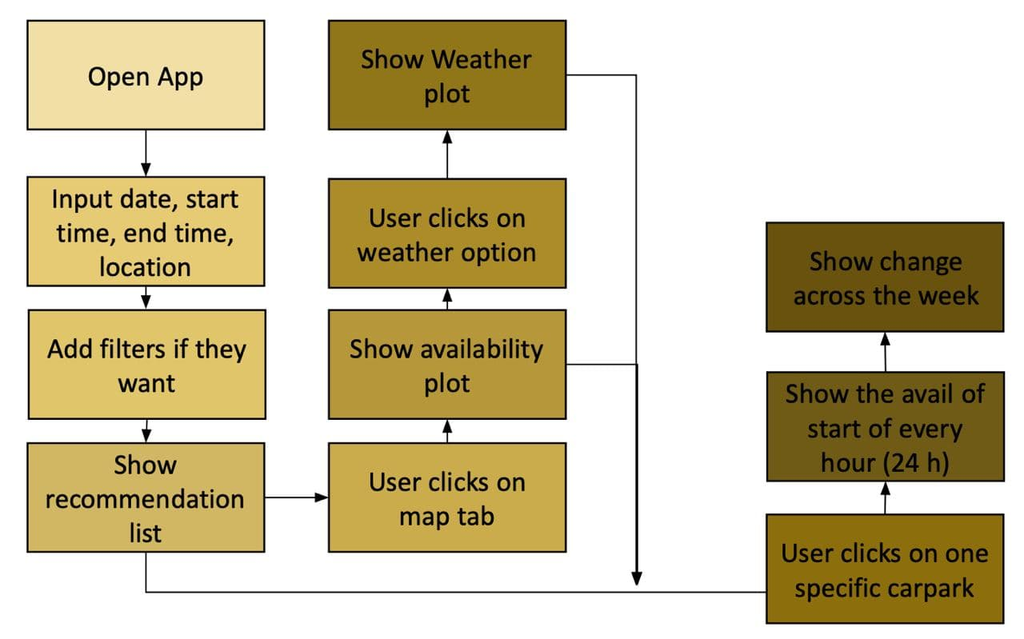

### App Development Process

Our team kick started the process by defining stages of the process of app development. With this structure, we were able to effectively track our progress. On top of that, this aligned our thought processes, allowing us to develop a deeper understanding of the project.

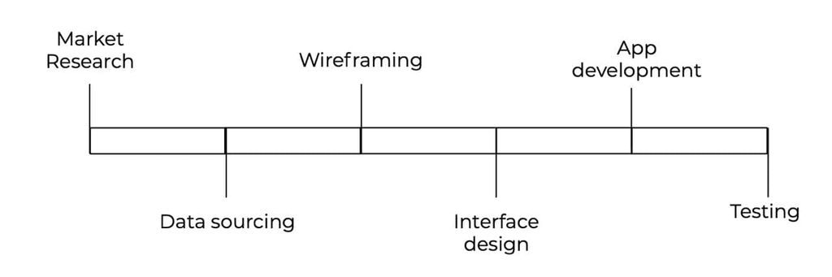

#### Market Research

Instead of finding ways to improve on existing apps in the market, our team wanted to work on a need that has no solution thus far, otherwise termed as a “Blue Ocean”. This way, our app will be able to capture consumers without competition. Our goal was to create a new market space hence, we had to conduct thorough research on current market practices on different problems. The problem of traffic congestion in Singapore caught our attention, pushing us to further investigate implications surrounding it. This led us to the problem of long waiting time for parking spaces.

#### Data sourcing

Upon identifying our target audience and their pain points, we discussed solutions to each pain point hence, deriving at a list of potential app features. With certain app features in mind, we sourced for data sets that would be useful.

#### Wire framing

After narrowing down on the app features, we mapped out the app flow so as to have better visualization.

#### Interface design

In this stage, we determine the best way to present information to users.

#### App development

**Feature 1: Locating available carparks according to user’s preferences**  
For this feature, there are 2 main parts – extracting the data from API and filtering data based on user’s choices.

Firstly, using the API for carpark availability in Singapore, we obtained **real-time updates** from each carpark. The data is extracted via JSON through webscraping and converted to a table. In the table, there is the carpark ID, carpark details (latitude and longtitude) and number of lots available per hour for the last 12 hours.

Next, for the filtering of data, it will generate a map and a table. The default timing is the current time. There is also an option to get a predicted carpark availability. This is done by averaging out the estimated lots available over the last 3 weeks. Carparks are divided into 3 categories – **“too little”**, **“limited”** and **“available”**. If carparks have less than 10 lots, they fall into “too little” and are not displayed even if in close proximity to the user. If carparks have less than 25 lots, they are “limited” and else, “available”. Based on the location input, the top 20 carparks will be displayed.

**Feature 2: Weather prediction**  
The weather prediction data is taken from the data.gov.sg API and converted to a dataframe. The forecast can be **up to 2 hours** in advance, it will contain the area and the weather type. The data is presented in the form of a **heatmap** with 12 different levels of weather types.

#### Testing

To ensure optimal results, we ran the app through multiple tests before launching it. Through the series of tests, we were able to identify faults and we have made amendments to them, deeming FAC ready for launch.

## Evaluation

#### Limitations in the Data

While a lot of data was available, due to the lack of consolidation, it was often difficult to combine and work with multiple datasets. For example, it would be ideal for this app to work for all carparks in Singapore. However, we were bounded to Housing & Development Board (HDB) carparks as most carparks were identified by a unique ID which was not necessarily consistent between different sources. We were unable to consolidate the necessary data from the websites of every single non-HDB carpark in Singapore.

Similarly, our weather prediction feature could be enhanced with more consolidated data. The data used for weather prediction was taken from a data.gov.sg api. For the 24-hour prediction, the data is segregated into North, South, East, West and Central. However, there is little information from the source API on how areas in Singapore are divided into these categories. In another source from data.gov.sg, Singapore was instead divided into North, North East, East, Central and West. Due to this misalignment, we found it better to restrict ourselves to the 2-hour prediction which set clearer boundaries.

It does not come as a surprise that there is a lack of consolidated data available online. There is no current market practice to drive the demand for standardisation. As market demand grows, we might find it more plausible to collect more desired data and constantly make improvements and upgrades to our app.

#### Limitations in our Analyses

One major dilemma we had when designing the prediction algorithm for the availability was the trade-off between computation time and accuracy.

We observed that in the short run, the weekly trend is relatively consistent. The trend for the same day of the week is similar across different weeks and the different trends across days of the week is also captured. Below, we have plotted the availability of one of the carparks over the past weeks as an example:

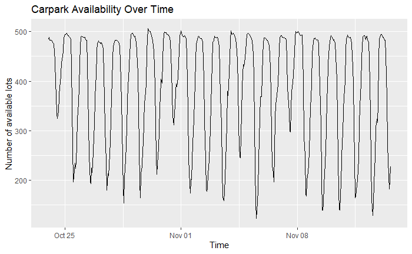

```r
getweekavail <- function(carpark_id) {
  end_date = Sys.time()
  start_date = as.Date(end_date - days(21))
  hour(start_date) = 0
  minute(start_date) = 1
  hour(end_date) = 0
  minute(end_date) = 0
  times = seq(start_date, end_date, by='hours')

  avail = NULL
  cooldown = 24

  for (i in 1:length(times)){
    cooldown = cooldown - 1
    if (cooldown == 0) {
      Sys.sleep(10)
      cooldown = 24
    }
    t = format(times[i], "%Y-%m-%dT%H:%M:%S")
    url = paste0("https://api.data.gov.sg/v1/transport/carpark-availability?date_time=", t)
    data = fromJSON(url)
    avail = as.data.frame(data$items$carpark_data) %>%
      filter(carpark_number == carpark_id) %>%
      mutate(date = times[i]) %>%
      rbind(avail)
  }

  return(unnest(avail))
}

data = getweekavail("HLM")
avail = data %>% group_by(date) %>%
  summarise(mean_avail = mean(as.numeric(lots_available)))


ggplot() +
  geom_line(data=avail, aes(x=date, y=mean_avail, group=1)) +
  labs(title="Carpark Availability Over Time") +
  ylab("Number of available lots") + xlab("Time")
```

Building off this assumption, we would take the data from the same week day of previous weeks and use the average to estimate future carpark availability. This prediction is simple and computationally faster. However, it also does not account for other factors like public holidays or seasonal changes. Hence the prediction may be less accurate. For example, in the plot, Thursday, 4 November 2021 is Diwali, a public holiday. Hence the trend is different on that day compare to other Thursdays.

Other methods such as regression were possible. However, these tended to have much larger computation time and could make the app frustrating to use for users.

Hence, we chose this method as it presented a good accuracy for the shortest computation time. If the computation time can be improved with better APIs or computation, we can explore other prediction methods.

### Future Adaptations

Despite a structured development process, there is bound to be loopholes that are overlooked. These loopholes will slowly surface and the team should be ready to update the app so as to retain consumers. On top of that, with the data and feedback collected over time from users, we will be able to discover new needs.

#### Price comparison system

One possible way to improve our app may be to introduce a **price comparison system**. Since all our recommended carparks currently are HDB carparks, their pricing systems are largely similar. However, if we manage to gain access to more data on other carparks,a price comparison feature may prove useful for future app users.

#### Traffic congestions indicator

This app tackles the challenge of finding a parking lot and the long waiting time. While there has been active intervention by the Singapore government to reduce car ownership, to curb traffic jams, it still needs more time to take effect. While waiting out for the intervention to take full effect, there is more that can be done. Many navigation apps allow road users to **check which roads are congested** at the moment. Over time as the app expands, this feature could be added as it coincides with FAC’s purpose – to make travelling as efficient as it can be.

##### Navigation

One of the future adaptation that the team would like to add to the app is to include a **navigation system**. Currently, our app gives carpark recommendations and address to the carparks are made available too. So after users have found their preferred carpark, they have to go to another app to get directions to the carpark. It would be more time-saving and convenient to stay on the app hence, our team would look into integrating a navigation system into our app and prepare for an update.

#### Monetisation

The new feature of an in-built navigation system coupled with the fact that the app is in an uncontested market space, there is high potential for implementing a **freemium model**. The navigation system and congestion indicator is expected to be well-received by users, hence these features can be introduced under the Premium Tier. The premium tier could possibly include a more detailed weather prediction.

## Conclusion

A 30 minutes trip should not be stretched out to an hour due to waiting around. With FAC, drivers can now plan out their trips in advance and we are confident that FAC will drastically reduce waiting time.

#### References

[TomTom Traffic Index, 2021](https://www.tomtom.com/en_gb/traffic-index/singapore-traffic/)